# Most harmful weather events for United States

## Synopsis

We will be analyzing data set called “Storm Data” which have data about weather events between 1950 and 2011 for United States. In this work i will find out what types of weather events are most harmful in terms of population health, property and crops.

## Data processing

Loading required libraries:

```r
library(plyr)
library(dplyr)
library(stringr)
library(sqldf)
library(ggplot2)
```

Lets load initial dataset (directly from downloaded archive), but extract only columns we will need in our work:

```r
  dfRAW <- read.csv("repdata-data-StormData.csv.bz2")

  dfFiltered <- dfRAW[, c("REFNUM", "EVTYPE",
                "FATALITIES", "INJURIES",
                "PROPDMG", "PROPDMGEXP",
                "CROPDMG", "CROPDMGEXP")]
```

Lets keep only records with meaningful values for fatalities and injuries:

```r
meaningful <- function(v)
{
  ifelse(!is.na(v) & ""!=v & 0 != v, TRUE, FALSE)
}

  dfFatInj <- filter(dfFiltered, (meaningful(FATALITIES)| meaningful(INJURIES)) )
```

Lets filter damage exponent columns (we will replace abbreviations with ready multipliers to make further calculations easier):

```r
dfDMG <- filter(dfFatInj, (meaningful(PROPDMG) | meaningful(CROPDMG)) )

  # replacing by ready magnitudes of 10 since sql extension does not have pow function
  dfDMG$PROPDMGEXP <- revalue(dfDMG$PROPDMGEXP, c("+"="1",
                                              "-"="1",
                                              "h"="100",
                                              "H"="100",
                                              "K"="1000",
                                              "m"="1000000",
                                              "M"="1000000",
                                              "B"="1000000000"))

  # cannot remove empty values with revalue
  dfDMG[dfDMG$PROPDMGEXP == "",]$PROPDMGEXP <- "1"

  dfDMG$CROPDMGEXP <- as.character(dfDMG$CROPDMGEXP)

  dfDMG$CROPDMGEXP <- revalue(dfDMG$CROPDMGEXP, c("?"="1",
                                              "k"="1000",
                                              "K"="1000",
                                              "m"="1000000",
                                              "M"="1000000",
                                              "B"="1000000000"))
  dfDMG[dfDMG$CROPDMGEXP == "",]$CROPDMGEXP <- "1"
```

Next, since actual file contents not matching with dataset description, we will be cleaning EVTYPE column by making several manual replacements (please note that this list is does not modifies data to match its description fully but only does it for most harmful events) :

```r
  dfClean <- dfDMG

  dfClean$EVTYPE <- str_trim(toupper(dfClean$EVTYPE))

  dfClean$EVTYPE <- revalue(dfClean$EVTYPE, c("TSTM WIND"="THUNDERSTORM WIND",
                                      "TSTM WIND/HAIL"="THUNDERSTORM WIND",
                                      "THUNDERSTORM WINDS"="THUNDERSTORM WIND",
                                      "THUNDERSTORMW"="THUNDERSTORM WIND",
                                      "THUNDERTORM WINDS"="THUNDERSTORM WIND",

                                      "HURRICANE"="HURRICANE/TYPHOON",
                                      "HURRICANE OPAL"="HURRICANE/TYPHOON",
                                      "HURRICANE OPAL/HIGH WINDS"="HURRICANE/TYPHOON",
                                      "TYPHOON"="HURRICANE/TYPHOON",
                                      "HURRICANE ERIN"="HURRICANE/TYPHOON",
                                      "HURRICANE EMILY"="HURRICANE/TYPHOON",

                                      "HEAT WAVE"="HEAT",

                                      "FOG"="FREEZING FOG",

                                      "HIGH WINDS"="HIGH WIND",
                                      "HIGH WINDS/COLD"="HIGH WIND",

                                      "SNOW"="HEAVY SNOW",

                                      "FLASH FLOOD/FLOOD"="FLOOD/FLASH FLOOD",
                                      "FLASH FLOODING"="FLOOD/FLASH FLOOD",
                                      "FLASH FLOODING/FLOOD"="FLOOD/FLASH FLOOD",
                                      "FLOODING"="FLOOD",

                                      "TROPICAL STORM GORDON"="TROPICAL STORM",

                                      "WILD/FOREST FIRE"="WILDFIRE",
                                      "WILD FIRES"="WILDFIRE",

                                      "WINTER WEATHER/MIX"="WINTER WEATHER",

                                      "WINTER STORMS"="WINTER STORM",
                                      "WINTER STORM HIGH WINDS"="WINTER STORM",

                                      "WATERSPOUT/TORNADO"="TORNADO",
                                      "TORNADO F3"="TORNADO",
                                      "TORNADO F2"="TORNADO"))
```

## Results:

Here we are using simple select with grouping by EVTYPE in order to find most harmful events.

```r
fatInj <- sqldf('
      SELECT
        EVTYPE,
        sum(FATALITIES)+SUM(INJURIES) total,
        sum(FATALITIES) fatalities,
        sum(INJURIES) injuries
      FROM
        dfClean
      GROUP BY
        EVTYPE
      HAVING
        total > 0
      ORDER BY
        total DESC
      LIMIT
        10')
propDmg <- sqldf('
      SELECT
        EVTYPE, SUM(PROPDMG * PROPDMGEXP) damage
      FROM
        dfClean
      GROUP BY
        EVTYPE
      HAVING
        damage >0
      ORDER BY
        damage DESC
      LIMIT
        10')

cropDmg <- sqldf('
      SELECT
        EVTYPE, SUM(CROPDMG * CROPDMGEXP) damage
      FROM
        dfClean
      GROUP BY
        EVTYPE
      HAVING
        damage >0
      ORDER BY
        damage DESC
      LIMIT
        10')

totalDmg <- sqldf('
      SELECT
        EVTYPE,
      SUM(PROPDMG * PROPDMGEXP) damageP,
      SUM(CROPDMG * CROPDMGEXP) damageC,
      SUM(PROPDMG * PROPDMGEXP) + SUM(CROPDMG * CROPDMGEXP) damageT
      FROM
        dfClean
      GROUP BY
        EVTYPE
      HAVING
        damageT >0
      ORDER BY
        damageT DESC
      LIMIT
        10')
```

Here is what we got:

```r
fatInj
```

```
##               EVTYPE total fatalities injuries
## 1            TORNADO 88782       5084    83698
## 2              FLOOD  7098        362     6736
## 3  THUNDERSTORM WIND  4897        303     4594
## 4        FLASH FLOOD  2106        601     1505
## 5          ICE STORM  1882         40     1842
## 6  HURRICANE/TYPHOON  1435        108     1327
## 7           WILDFIRE  1276         73     1203
## 8          HIGH WIND  1274        173     1101
## 9       WINTER STORM  1127         91     1036
## 10              HEAT  1020         81      939
```

```r
propDmg
```

```
##               EVTYPE      damage
## 1            TORNADO 41937213080
## 2  HURRICANE/TYPHOON 38313605000
## 3              FLOOD  6683351640
## 4     TROPICAL STORM  6560656000
## 5       WINTER STORM  5281662500
## 6           WILDFIRE  4667112200
## 7   STORM SURGE/TIDE  4004000000
## 8        FLASH FLOOD  3901610800
## 9               HAIL  3505785700
## 10         HIGH WIND  3322379095
```

```r
cropDmg
```

```
##               EVTYPE     damage
## 1  HURRICANE/TYPHOON 3824850800
## 2     EXCESSIVE HEAT  492400000
## 3          HIGH WIND  354630150
## 4           WILDFIRE  188627000
## 5  THUNDERSTORM WIND  184893550
## 6               HAIL  166300000
## 7     TROPICAL STORM  157765000
## 8            TORNADO  141477000
## 9              FLOOD  132622500
## 10          BLIZZARD  112050000
```

```r
totalDmg
```

```
##               EVTYPE     damageP    damageC     damageT
## 1  HURRICANE/TYPHOON 38313605000 3824850800 42138455800
## 2            TORNADO 41937213080  141477000 42078690080
## 3              FLOOD  6683351640  132622500  6815974140
## 4     TROPICAL STORM  6560656000  157765000  6718421000
## 5       WINTER STORM  5281662500   15783000  5297445500
## 6           WILDFIRE  4667112200  188627000  4855739200
## 7   STORM SURGE/TIDE  4004000000          0  4004000000
## 8        FLASH FLOOD  3901610800   47966750  3949577550
## 9          HIGH WIND  3322379095  354630150  3677009245
## 10              HAIL  3505785700  166300000  3672085700
```

Lets take a look on events caused most damage to population health.

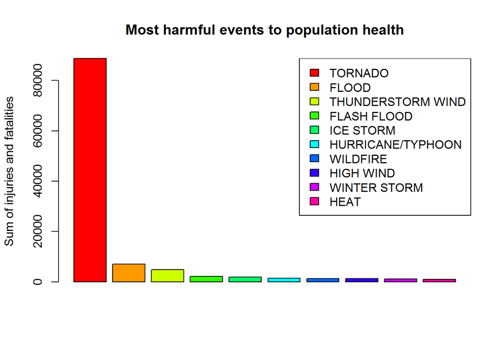

```r
barplot(fatInj$total, col=rainbow(nrow(fatInj)),
        main="Most harmful events to population health",
        ylab="Sum of injuries and fatalities")
legend("topright", fatInj$EVTYPE, fill=rainbow(nrow(fatInj)) )
```

As we can see, the most harmful weather event is TORNADO.

Lets see events caused most economic impact:

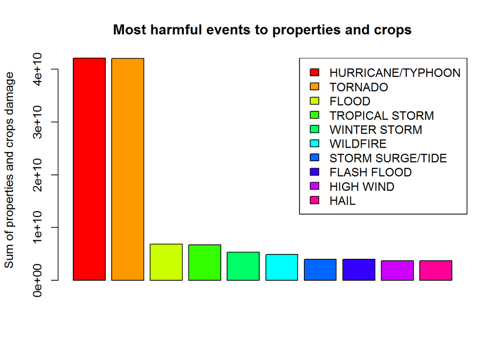

```r
barplot(totalDmg$damageT, col=rainbow(nrow(totalDmg)),
        main="Most harmful events to properties and crops",
        ylab="Sum of properties and crops damage")
legend("topright", totalDmg$EVTYPE, fill=rainbow(nrow(totalDmg)) )
```

As we can see, here the most harmful weather events are HURRICANE and TORNADO.